# Representing sequencing data in R and Bioconductor

Mark Dunning

Last modified: 23 Nov 2015

# Overview

# Aims

- By the end of this session you should be familiar with
- How to create and compare genomic intervals
- How DNA sequences are represented in R
- How to read bam files into R
- Interactions between the packages

# Motivation

- We will often want to find information about the genomic region around the reads
  - genes, transcripts, exons
  - genomic sequence

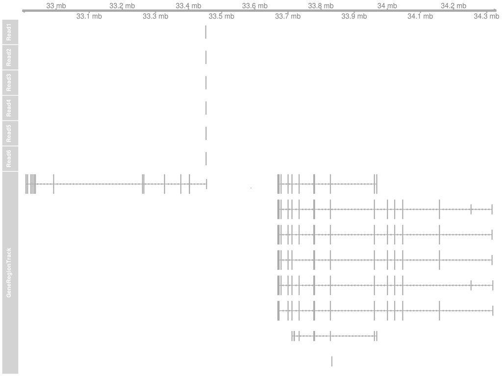

# Core data-type 1: Genome Intervals

# IRanges

- A Genome is typically represented as linear sequence
- Ranges are an ordered set of consecutive integers defined by a start and end position
  - start $\le$ end
- Ranges are a common scaffold for many genomic analyses
- Ranges can be associated with genomic information (e.g. gene name) or data derived from analysis (e.g. counts)
- The `IRanges` package in Bioconductor allows us to work with intervals
  - one of the aims of Bioconductor is to encourage core object-types and functions
  - `IRanges` is an example of this

# IRanges is crucial for many packages

Just some of the packages that *depend* on [IRanges](http://bioconductor.org/packages/release/bioc/html/IRanges.html)

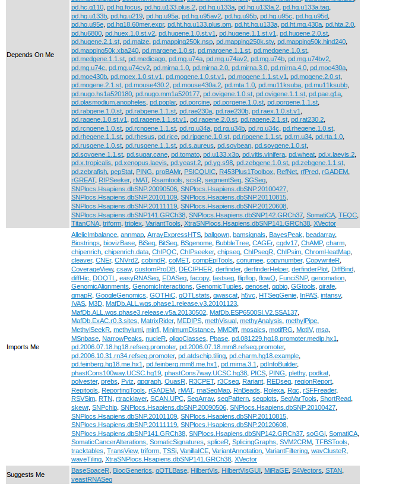

# IRanges paper

[figure not shown]

# Example

Suppose we want to capture information on the following intervals

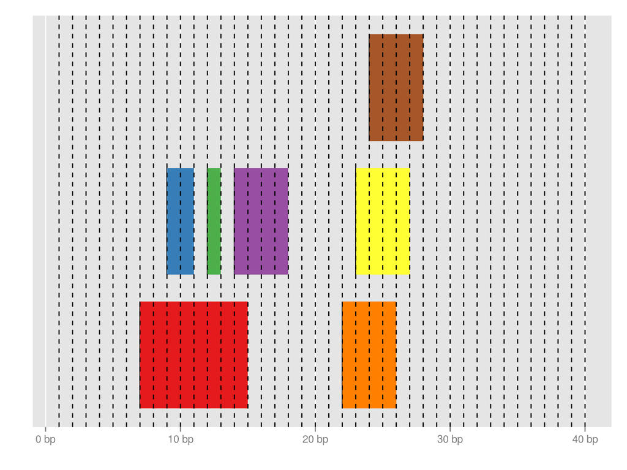

# Creating the object

- The `IRanges` function from the `IRanges` package is used to *construct* a new object
  - think `data.frame`, `vector` or `matrix`
  - it’s structure is quite unlike anything we’ve seen before

```r
library(IRanges)
ir <- IRanges(
start = c(7,9,12,14,22:24),
end=c(15,11,13,18,26,27,28))
str(ir)
```

```
## Formal class 'IRanges' [package "IRanges"] with 6 slots
##   ..@ start          : int [1:7] 7 9 12 14 22 23 24
##   ..@ width          : int [1:7] 9 3 2 5 5 5 5
##   ..@ NAMES          : NULL
##   ..@ elementType    : chr "integer"
##   ..@ elementMetadata: NULL
##   ..@ metadata       : list()
```

# Display the object

- Typing the name of the object will print a summary of the object to the screen
  - useful compared to display methods for data frames, which print the whole object
- the square brackets `[]` should give a hint about how to access the data…

```r
ir
```

```
## IRanges of length 7
##     start end width
## [1]     7  15     9
## [2]     9  11     3
## [3]    12  13     2
## [4]    14  18     5
## [5]    22  26     5
## [6]    23  27     5
## [7]    24  28     5
```

# Adding metadata

We can give our ranges names

```r
ir <- IRanges(
start = c(7,9,12,14,22:24),
end=c(15,11,13,18,26,27,28),names=LETTERS[1:7])
ir
```

```
## IRanges of length 7
##     start end width names
## [1]     7  15     9     A
## [2]     9  11     3     B
## [3]    12  13     2     C
## [4]    14  18     5     D
## [5]    22  26     5     E
## [6]    23  27     5     F
## [7]    24  28     5     G
```

# Ranges as vectors

- `IRanges` can be treated as if they were *vectors*
  - no new rules to learn
    - if we can subset vectors, we can subset ranges
  - vector operations are efficient
  - Remember, square brackets `[` to subset
  - Inside the brackets, put a numeric vector to specify the `indices` that you want values for
    - e.g. get the first two intervals in the object using the `:` shortcut

```r
ir[1:2]
```

```
## IRanges of length 2
##     start end width names
## [1]     7  15     9     A
## [2]     9  11     3     B
```

```r
ir[c(2,4,6)]
```

```
## IRanges of length 3
##     start end width names
## [1]     9  11     3     B
## [2]    14  18     5     D
## [3]    23  27     5     F
```

# Accessing the object

- If we want to extract the properties of the object, the package authors have provided some useful functions
  - we call these *accessor* functions
  - We don’t need to know the details of how the objects and implemented to access the data
  - the authors are free to change the implementation at any time
    - we shouldn’t notice the difference
  - the result is a vector with the same length as the number of intervals

```r
start(ir)
```

```
## [1]  7  9 12 14 22 23 24
```

```r
end(ir)
```

```
## [1] 15 11 13 18 26 27 28
```

```r
width(ir)
```

```
## [1] 9 3 2 5 5 5 5
```

# More-complex subsetting

- Recall that ‘*logical*’ vectors can be used in subsetting
  - i.e. `TRUE` or `FALSE`
- Such a vector can be derived using a comparison operator
  - `<`, `>`, `==`

```r
width(ir) == 5
```

```
## [1] FALSE FALSE FALSE  TRUE  TRUE  TRUE  TRUE
```

```r
ir[width(ir)==5]
```

```
## IRanges of length 4
##     start end width names
## [1]    14  18     5     D
## [2]    22  26     5     E
## [3]    23  27     5     F
## [4]    24  28     5     G
```

# More-complex subsetting

```r
start(ir) > 10
```

```
## [1] FALSE FALSE  TRUE  TRUE  TRUE  TRUE  TRUE
```

```r
end(ir) < 27
```

```
## [1]  TRUE  TRUE  TRUE  TRUE  TRUE FALSE FALSE
```

```r
ir[start(ir) > 10]
```

```
## IRanges of length 5
##     start end width names
## [1]    12  13     2     C
## [2]    14  18     5     D
## [3]    22  26     5     E
## [4]    23  27     5     F
## [5]    24  28     5     G
```

# More-complex subsetting

- Multiple logical vectors can be combined using `&` (and), `|` (or)
  - eg intervals that start after 10, **and** before 27

```r
ir[end(ir) < 27]
```

```
## IRanges of length 5
##     start end width names
## [1]     7  15     9     A
## [2]     9  11     3     B
## [3]    12  13     2     C
## [4]    14  18     5     D
## [5]    22  26     5     E
```

```r
ir[start(ir) > 10 & end(ir) < 27]
```

```
## IRanges of length 3
##     start end width names
## [1]    12  13     2     C
## [2]    14  18     5     D
## [3]    22  26     5     E
```

# Manipulating Ranges

# Lots of common use-cases are implemented

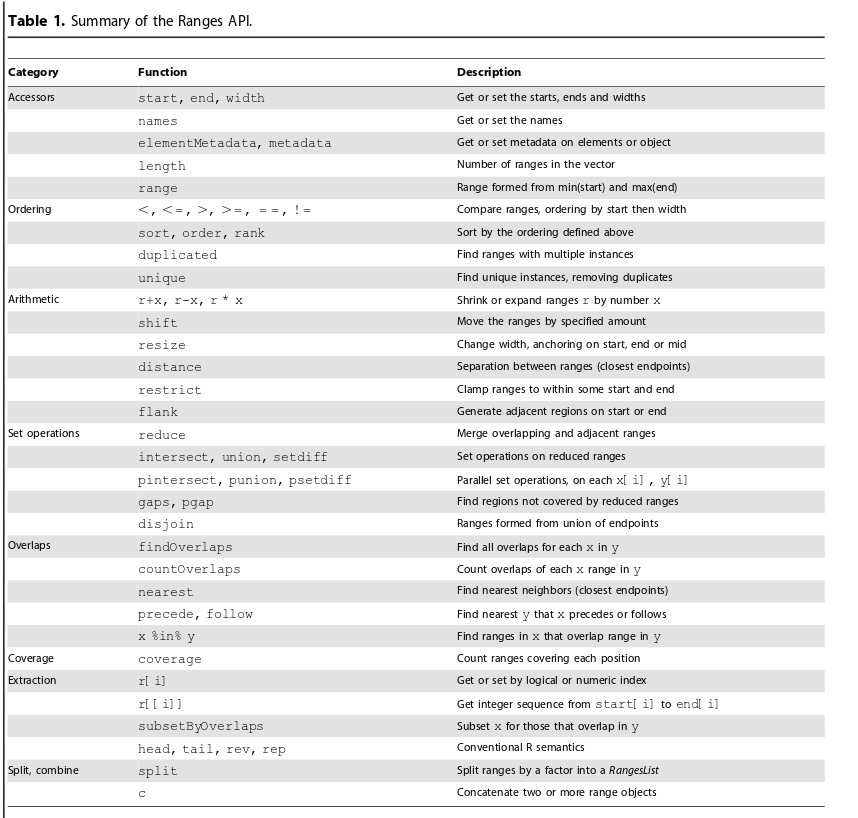

# Shifting

e.g. sliding windows

```r
ir
```

```
## IRanges of length 7
##     start end width names
## [1]     7  15     9     A
## [2]     9  11     3     B
## [3]    12  13     2     C
## [4]    14  18     5     D
## [5]    22  26     5     E
## [6]    23  27     5     F
## [7]    24  28     5     G
```

```r
shift(ir, 5)
```

```
## IRanges of length 7
##     start end width names
## [1]    12  20     9     A
## [2]    14  16     3     B
## [3]    17  18     2     C
## [4]    19  23     5     D
## [5]    27  31     5     E
## [6]    28  32     5     F
## [7]    29  33     5     G
```

# Shifting

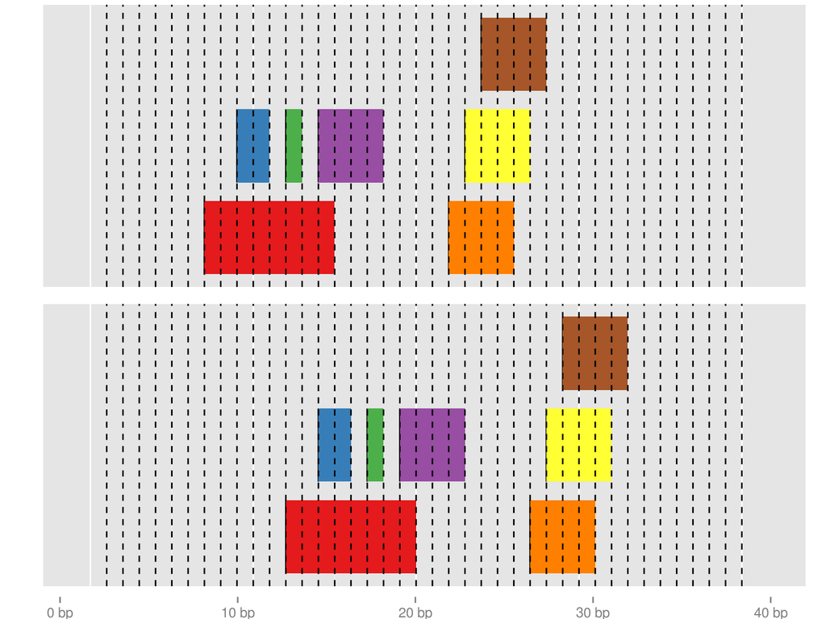

# Shifting

Size of shift doesn’t need to be constant

```r
ir
```

```
## IRanges of length 7
##     start end width names
## [1]     7  15     9     A
## [2]     9  11     3     B
## [3]    12  13     2     C
## [4]    14  18     5     D
## [5]    22  26     5     E
## [6]    23  27     5     F
## [7]    24  28     5     G
```

```r
shift(ir, 7:1)
```

```
## IRanges of length 7
##     start end width names
## [1]    14  22     9     A
## [2]    15  17     3     B
## [3]    17  18     2     C
## [4]    18  22     5     D
## [5]    25  29     5     E
## [6]    25  29     5     F
## [7]    25  29     5     G
```

# Shifting

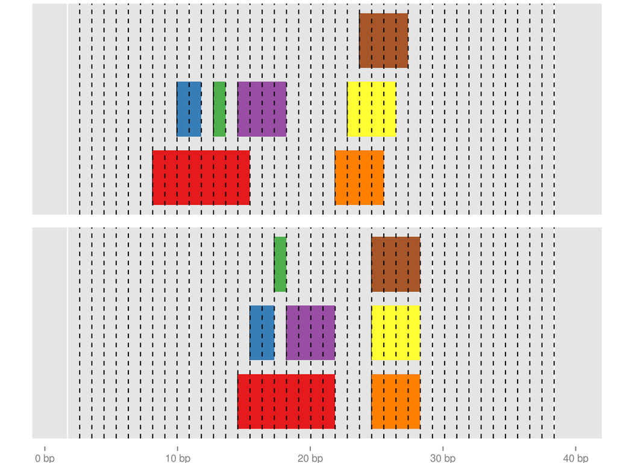

# Resize

e.g. trimming reads

```r
ir
```

```
## IRanges of length 7
##     start end width names
## [1]     7  15     9     A
## [2]     9  11     3     B
## [3]    12  13     2     C
## [4]    14  18     5     D
## [5]    22  26     5     E
## [6]    23  27     5     F
## [7]    24  28     5     G
```

```r
resize(ir,3)
```

```
## IRanges of length 7
##     start end width names
## [1]     7   9     3     A
## [2]     9  11     3     B
## [3]    12  14     3     C
## [4]    14  16     3     D
## [5]    22  24     3     E
## [6]    23  25     3     F
## [7]    24  26     3     G
```

# Resize

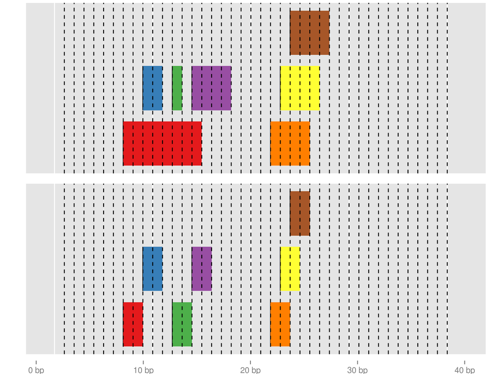

# Coverage

- Often we want to know how much sequencing we have at particular positions
  - i.e. depth of coverage

`coverage` returns a *Run Length Encoding* - an efficient representation of repeated values

```r
cvg <- coverage(ir)
cvg
```

```
## integer-Rle of length 28 with 10 runs
##   Lengths: 6 2 7 3 3 1 1 3 1 1
##   Values : 0 1 2 1 0 1 2 3 2 1
```

```r
as.vector(cvg)
```

```
##  [1] 0 0 0 0 0 0 1 1 2 2 2 2 2 2 2 1 1 1 0 0 0 1 2 3 3 3 2 1
```

# Coverage Results

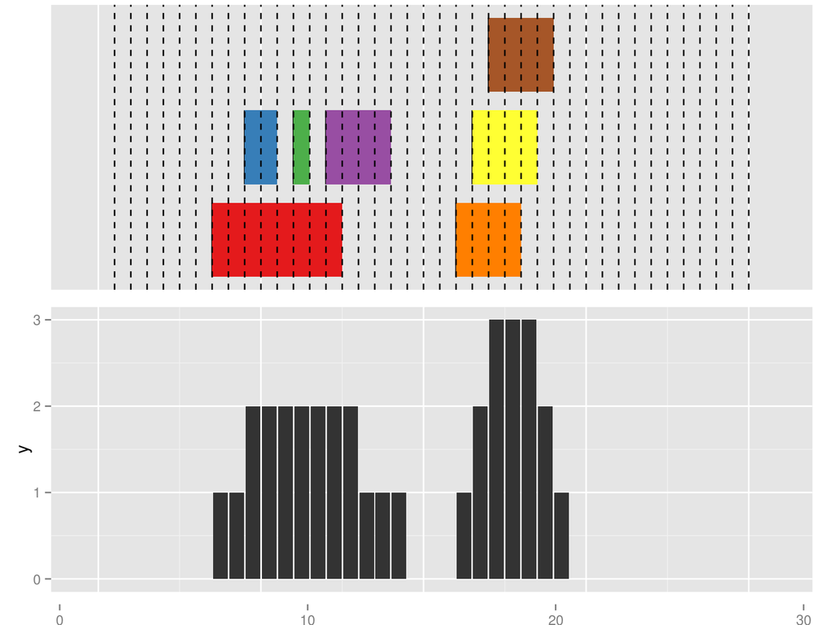

# Overlapping

e.g. counting - The terminology of overlapping defines a *query* and a *subject*

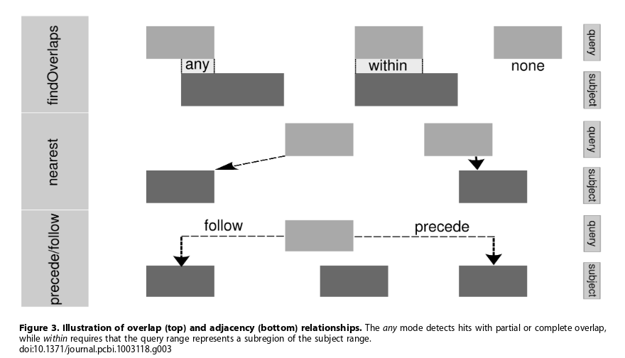

# Overlaps

- lets start be defining a new set of ranges

```r
ir3 <- IRanges(start = c(1, 14, 27), end = c(13,
    18, 30),names=c("X","Y","Z"))
ir3
```

```
## IRanges of length 3
##     start end width names
## [1]     1  13    13     X
## [2]    14  18     5     Y
## [3]    27  30     4     Z
```

# Overlaps

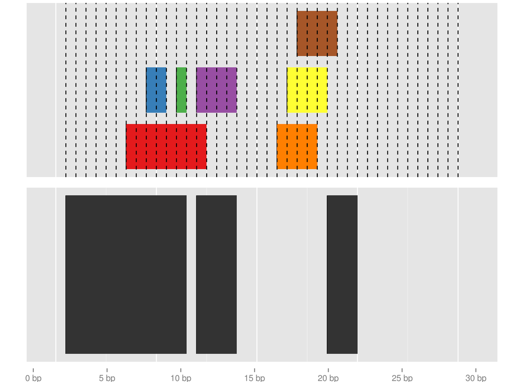

# Overlaps

- The `findOverlaps` function is used for overlap
  - the output isn’t immediately obvious
  - length of output is the number of *hits*
    - each hit is defined by a subject and query index
  - require accessor functions to get the data; `queryHits` and `subjectHits`

```r
query <- ir
subject <- ir3
ov <- findOverlaps(query, subject)
ov
```

```
## Hits object with 7 hits and 0 metadata columns:
##       queryHits subjectHits
##       <integer>   <integer>
##   [1]         1           1
##   [2]         1           2
##   [3]         2           1
##   [4]         3           1
##   [5]         4           2
##   [6]         6           3
##   [7]         7           3
##   -------
##   queryLength: 7
##   subjectLength: 3
```

# queryHits and subjectHits

- `queryHits` returns *indices* from the *query*
  - each query may overlap with many in the subject

```r
queryHits(ov)
```

```
## [1] 1 1 2 3 4 6 7
```

- `subjectHits` returns *indices* from the *subject*
  - each subject range may overlap with many in the query

```r
subjectHits(ov)
```

```
## [1] 1 2 1 1 2 3 3
```

- e.g. 1 from the query overlaps with 1 from the subject

# Overlap example - First hit

```r
query[queryHits(ov)[1]]
```

```
## IRanges of length 1
##     start end width names
## [1]     7  15     9     A
```

```r
subject[subjectHits(ov)[1]]
```

```
## IRanges of length 1
##     start end width names
## [1]     1  13    13     X
```

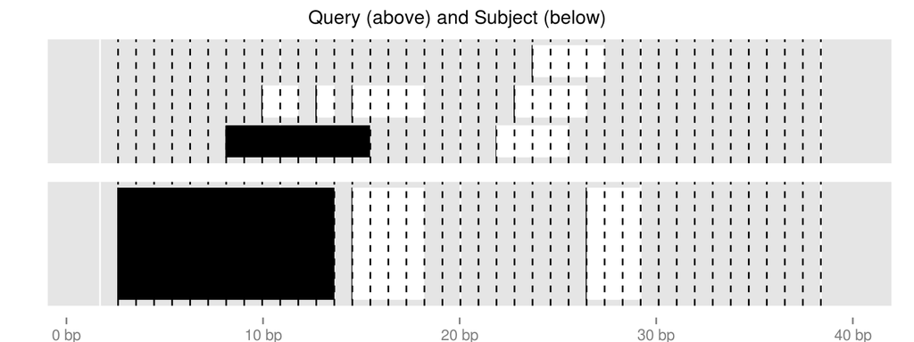

# Overlap example - second hit

```r
query[queryHits(ov)[2]]
```

```
## IRanges of length 1
##     start end width names
## [1]     7  15     9     A
```

```r
subject[subjectHits(ov)[2]]
```

```
## IRanges of length 1
##     start end width names
## [1]    14  18     5     Y
```

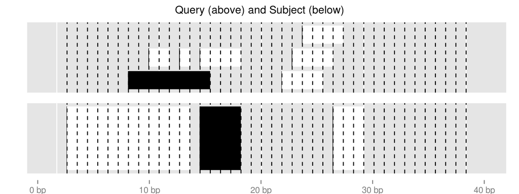

# Overlap example - Third hit

```r
query[queryHits(ov)[3]]
```

```
## IRanges of length 1
##     start end width names
## [1]     9  11     3     B
```

```r
subject[subjectHits(ov)[3]]
```

```
## IRanges of length 1
##     start end width names
## [1]     1  13    13     X
```

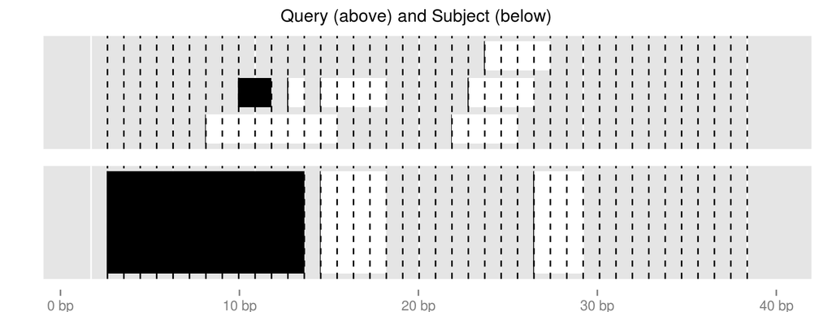

# Counting

- If we just wanted to count the number of overlaps for each range, we can use `countOverlaps`
  - result is a vector with length the number of intervals in query
  - e.g. interval 1 in the query overlaps with 2 intervals in the subject

```r
countOverlaps(query,subject)
```

```
## A B C D E F G
## 2 1 1 1 0 1 1
```

- Order of arguments is important

```r
countOverlaps(subject,query)
```

```
## X Y Z
## 3 2 2
```

# Modify overlap criteria

- There are various ways of defining an overlap
- We can be more stringent by stating that all positions need to be in common

```r
findOverlaps(query,subject,type="within")
```

```
## Hits object with 3 hits and 0 metadata columns:
##       queryHits subjectHits
##       <integer>   <integer>
##   [1]         2           1
##   [2]         3           1
##   [3]         4           2
##   -------
##   queryLength: 7
##   subjectLength: 3
```

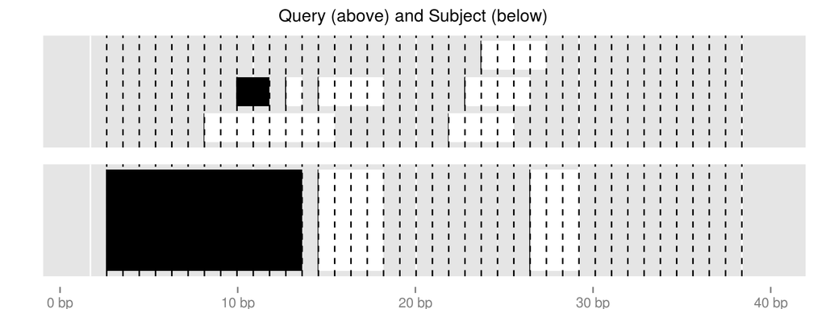

# More stringent overlap

```r
findOverlaps(query,subject,type="within")
```

```
## Hits object with 3 hits and 0 metadata columns:
##       queryHits subjectHits
##       <integer>   <integer>
##   [1]         2           1
##   [2]         3           1
##   [3]         4           2
##   -------
##   queryLength: 7
##   subjectLength: 3
```

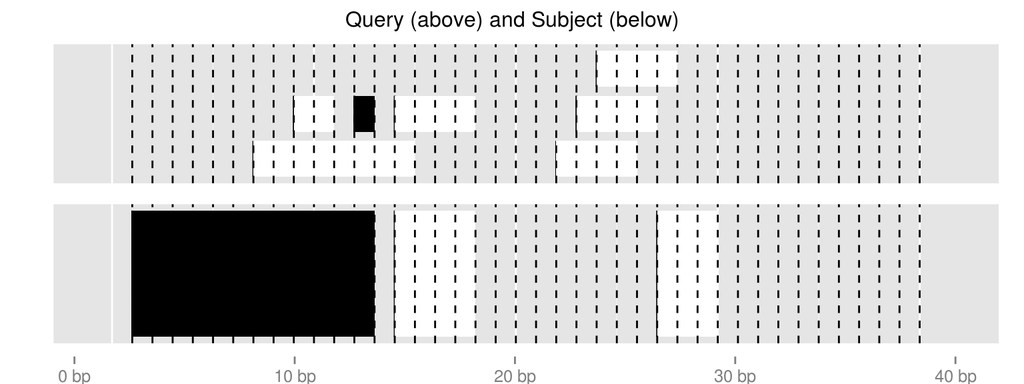

# More strigent overlap

```r
findOverlaps(query,subject,type="within")
```

```
## Hits object with 3 hits and 0 metadata columns:
##       queryHits subjectHits
##       <integer>   <integer>
##   [1]         2           1
##   [2]         3           1
##   [3]         4           2
##   -------
##   queryLength: 7
##   subjectLength: 3
```

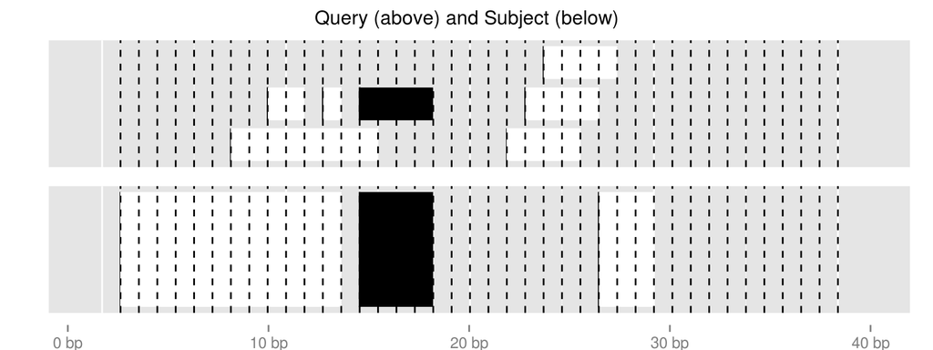

# Intersection

- Rather than counting, we might want to know which positions are in common

```r
intersect(ir,ir3)
```

```
## IRanges of length 2
##     start end width
## [1]     7  18    12
## [2]    27  28     2
```

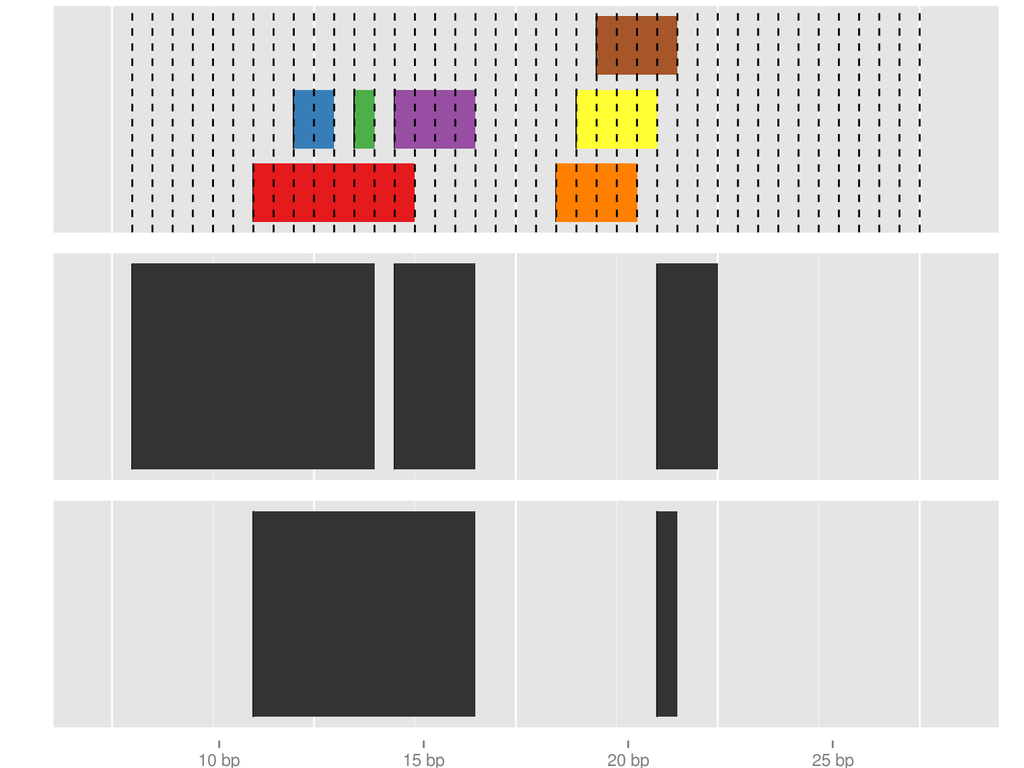

# Subtraction

- Or which positions are missing

```r
setdiff(ir,ir3)
```

```
## IRanges of length 1
##     start end width
## [1]    22  26     5
```

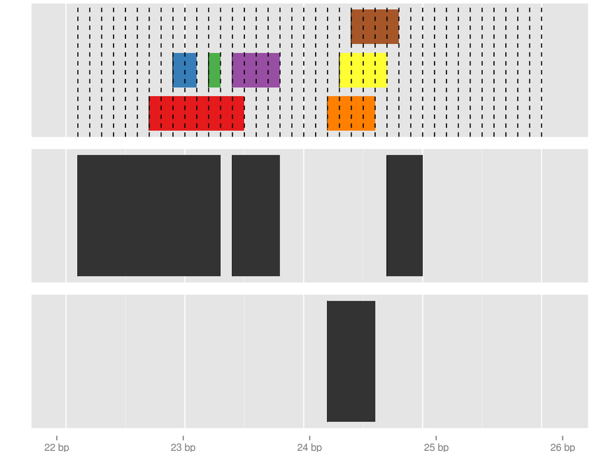